# Analysis

Ching Hong Fung

9/10/2021

## Setting up environment and loading data

Loading up a few packages to help with data wrangling. Setting the work directory to where the csv files are saved.

```r
library(tidyverse)  #helps wrangle data
library(lubridate)  #helps wrangle date attributes
library(ggplot2)  #helps visualize data
setwd("/Users/asus/Desktop/Coursera/Data Analytics - Google/Capstone1")
```

Loading the twelve csv files into dataframes.

```r
m8_2021 <- read.csv("202108-divvy-tripdata.csv")
m7_2021 <- read.csv("202107-divvy-tripdata.csv")
m6_2021 <- read.csv("202106-divvy-tripdata.csv")
m5_2021 <- read.csv("202105-divvy-tripdata.csv")
m4_2021 <- read.csv("202104-divvy-tripdata.csv")
m3_2021 <- read.csv("202103-divvy-tripdata.csv")
m2_2021 <- read.csv("202102-divvy-tripdata.csv")
m1_2021 <- read.csv("202101-divvy-tripdata.csv")
m12_2020 <- read.csv("202012-divvy-tripdata.csv")
m11_2020 <- read.csv("202011-divvy-tripdata.csv")
m10_2020 <- read.csv("202010-divvy-tripdata.csv")
m9_2020 <- read.csv("202009-divvy-tripdata.csv")
```

## Wrangle data and combine into a single dataframe

Using the colnames() function to check all the csv files have the same column attributes.

```r
colnames(m8_2021)
```

```
##  [1] "ride_id"            "rideable_type"      "started_at"
##  [4] "ended_at"           "start_station_name" "start_station_id"
##  [7] "end_station_name"   "end_station_id"     "start_lat"
## [10] "start_lng"          "end_lat"            "end_lng"
## [13] "member_casual"      "ride_length"        "day_of_week"
```

```r
colnames(m7_2021)
```

```
##  [1] "ride_id"            "rideable_type"      "started_at"
##  [4] "ended_at"           "start_station_name" "start_station_id"
##  [7] "end_station_name"   "end_station_id"     "start_lat"
## [10] "start_lng"          "end_lat"            "end_lng"
## [13] "member_casual"      "ride_length"        "day_of_week"
```

```r
colnames(m6_2021)
```

```
##  [1] "ride_id"            "rideable_type"      "started_at"
##  [4] "ended_at"           "start_station_name" "start_station_id"
##  [7] "end_station_name"   "end_station_id"     "start_lat"
## [10] "start_lng"          "end_lat"            "end_lng"
## [13] "member_casual"      "ride_length"        "day_of_week"
```

```r
colnames(m5_2021)
```

```
##  [1] "ride_id"            "rideable_type"      "started_at"
##  [4] "ended_at"           "start_station_name" "start_station_id"
##  [7] "end_station_name"   "end_station_id"     "start_lat"
## [10] "start_lng"          "end_lat"            "end_lng"
## [13] "member_casual"      "ride_length"        "day_of_week"
```

```r
colnames(m4_2021)
```

```
##  [1] "ride_id"            "rideable_type"      "started_at"
##  [4] "ended_at"           "start_station_name" "start_station_id"
##  [7] "end_station_name"   "end_station_id"     "start_lat"
## [10] "start_lng"          "end_lat"            "end_lng"
## [13] "member_casual"      "ride_length"        "day_of_week"
```

```r
colnames(m3_2021)
```

```
##  [1] "ride_id"            "rideable_type"      "started_at"
##  [4] "ended_at"           "start_station_name" "start_station_id"
##  [7] "end_station_name"   "end_station_id"     "start_lat"
## [10] "start_lng"          "end_lat"            "end_lng"
## [13] "member_casual"      "ride_length"        "day_of_week"
```

```r
colnames(m2_2021)
```

```
##  [1] "ride_id"            "rideable_type"      "started_at"
##  [4] "ended_at"           "start_station_name" "start_station_id"
##  [7] "end_station_name"   "end_station_id"     "start_lat"
## [10] "start_lng"          "end_lat"            "end_lng"
## [13] "member_casual"      "ride_length"        "day_of_week"
```

```r
colnames(m1_2021)
```

```
##  [1] "ride_id"            "rideable_type"      "started_at"
##  [4] "ended_at"           "start_station_name" "start_station_id"
##  [7] "end_station_name"   "end_station_id"     "start_lat"
## [10] "start_lng"          "end_lat"            "end_lng"
## [13] "member_casual"      "ride_length"        "day_of_week"
```

```r
colnames(m12_2020)
```

```
##  [1] "ride_id"            "rideable_type"      "started_at"
##  [4] "ended_at"           "start_station_name" "start_station_id"
##  [7] "end_station_name"   "end_station_id"     "start_lat"
## [10] "start_lng"          "end_lat"            "end_lng"
## [13] "member_casual"      "ride_length"        "day_of_week"
```

```r
colnames(m11_2020)
```

```
##  [1] "ride_id"            "rideable_type"      "started_at"
##  [4] "ended_at"           "start_station_name" "start_station_id"
##  [7] "end_station_name"   "end_station_id"     "start_lat"
## [10] "start_lng"          "end_lat"            "end_lng"
## [13] "member_casual"      "ride_length"        "day_of_week"
```

```r
colnames(m10_2020)
```

```
##  [1] "ride_id"            "rideable_type"      "started_at"
##  [4] "ended_at"           "start_station_name" "start_station_id"
##  [7] "end_station_name"   "end_station_id"     "start_lat"
## [10] "start_lng"          "end_lat"            "end_lng"
## [13] "member_casual"      "ride_length"        "day_of_week"
```

```r
colnames(m9_2020)
```

```
##  [1] "ride_id"            "rideable_type"      "started_at"
##  [4] "ended_at"           "start_station_name" "start_station_id"
##  [7] "end_station_name"   "end_station_id"     "start_lat"
## [10] "start_lng"          "end_lat"            "end_lng"
## [13] "member_casual"      "ride_length"        "day_of_week"
```

Using str() to view the data types of the columns. Realised some datatypes don’t match among the dataframes.

```r
str(m8_2021)
```

```
## 'data.frame':    804352 obs. of  15 variables:
##  $ ride_id           : chr  "99103BB87CC6C1BB" "EAFCCCFB0A3FC5A1" "9EF4F46C57AD234D" "5834D3208BFAF1DA" ...
##  $ rideable_type     : chr  "electric_bike" "electric_bike" "electric_bike" "electric_bike" ...
##  $ started_at        : chr  "10-08-21 17:15" "10-08-21 17:23" "21-08-21 2:34" "21-08-21 6:52" ...
##  $ ended_at          : chr  "10-08-21 17:22" "10-08-21 17:39" "21-08-21 2:50" "21-08-21 7:08" ...
##  $ start_station_name: chr  "" "" "" "" ...
##  $ start_station_id  : chr  "" "" "" "" ...
##  $ end_station_name  : chr  "" "" "" "" ...
##  $ end_station_id    : chr  "" "" "" "" ...
##  $ start_lat         : num  41.8 41.8 42 42 41.8 ...
##  $ start_lng         : num  -87.7 -87.7 -87.7 -87.7 -87.6 ...
##  $ end_lat           : num  41.8 41.8 42 42 41.8 ...
##  $ end_lng           : num  -87.7 -87.6 -87.7 -87.7 -87.6 ...
##  $ member_casual     : chr  "member" "member" "member" "member" ...
##  $ ride_length       : chr  "0:06:55" "0:16:10" "0:16:13" "0:15:18" ...
##  $ day_of_week       : int  3 3 7 7 5 5 5 6 3 4 ...
```

```r
str(m7_2021)
```

```
## 'data.frame':    822410 obs. of  15 variables:
##  $ ride_id           : chr  "0A1B623926EF4E16" "B2D5583A5A5E76EE" "6F264597DDBF427A" "379B58EAB20E8AA5" ...
##  $ rideable_type     : chr  "docked_bike" "classic_bike" "classic_bike" "classic_bike" ...
##  $ started_at        : chr  "02-07-21 14:44" "07-07-21 16:57" "25-07-21 11:30" "08-07-21 22:08" ...
##  $ ended_at          : chr  "02-07-21 15:19" "07-07-21 17:16" "25-07-21 11:48" "08-07-21 22:23" ...
##  $ start_station_name: chr  "Michigan Ave & Washington St" "California Ave & Cortez St" "Wabash Ave & 16th St" "California Ave & Cortez St" ...
##  $ start_station_id  : chr  "13001" "17660" "SL-012" "17660" ...
##  $ end_station_name  : chr  "Halsted St & North Branch St" "Wood St & Hubbard St" "Rush St & Hubbard St" "Carpenter St & Huron St" ...
##  $ end_station_id    : chr  "KA1504000117" "13432" "KA1503000044" "13196" ...
##  $ start_lat         : num  41.9 41.9 41.9 41.9 41.9 ...
##  $ start_lng         : num  -87.6 -87.7 -87.6 -87.7 -87.7 ...
##  $ end_lat           : num  41.9 41.9 41.9 41.9 41.9 ...
##  $ end_lng           : num  -87.6 -87.7 -87.6 -87.7 -87.7 ...
##  $ member_casual     : chr  "casual" "casual" "member" "member" ...
##  $ ride_length       : chr  "0:35:22" "0:18:27" "0:17:50" "0:15:02" ...
##  $ day_of_week       : int  6 4 1 5 4 5 4 7 6 5 ...
```

```r
str(m6_2021)
```

```
## 'data.frame':    729595 obs. of  15 variables:
##  $ ride_id           : chr  "99FEC93BA843FB20" "06048DCFC8520CAF" "9598066F68045DF2" "B03C0FE48C412214" ...
##  $ rideable_type     : chr  "electric_bike" "electric_bike" "electric_bike" "electric_bike" ...
##  $ started_at        : chr  "13-06-21 14:31" "04-06-21 11:18" "04-06-21 9:49" "03-06-21 19:56" ...
##  $ ended_at          : chr  "13-06-21 14:34" "04-06-21 11:24" "04-06-21 9:55" "03-06-21 20:21" ...
##  $ start_station_name: chr  "" "" "" "" ...
##  $ start_station_id  : chr  "" "" "" "" ...
##  $ end_station_name  : chr  "" "" "" "" ...
##  $ end_station_id    : chr  "" "" "" "" ...
##  $ start_lat         : num  41.8 41.8 41.8 41.8 41.8 ...
##  $ start_lng         : num  -87.6 -87.6 -87.6 -87.6 -87.6 ...
##  $ end_lat           : num  41.8 41.8 41.8 41.8 41.8 ...
##  $ end_lng           : num  -87.6 -87.6 -87.6 -87.6 -87.6 ...
##  $ member_casual     : chr  "member" "member" "member" "member" ...
##  $ ride_length       : chr  "0:02:43" "0:06:17" "0:05:59" "0:25:50" ...
##  $ day_of_week       : int  1 6 6 5 6 5 5 5 5 4 ...
```

```r
str(m5_2021)
```

```
## 'data.frame':    531633 obs. of  15 variables:
##  $ ride_id           : chr  "C809ED75D6160B2A" "DD59FDCE0ACACAF3" "0AB83CB88C43EFC2" "7881AC6D39110C60" ...
##  $ rideable_type     : chr  "electric_bike" "electric_bike" "electric_bike" "electric_bike" ...
##  $ started_at        : chr  "30-05-21 11:58" "30-05-21 11:29" "30-05-21 14:24" "30-05-21 14:25" ...
##  $ ended_at          : chr  "30-05-21 12:10" "30-05-21 12:14" "30-05-21 14:25" "30-05-21 14:41" ...
##  $ start_station_name: chr  "" "" "" "" ...
##  $ start_station_id  : chr  "" "" "" "" ...
##  $ end_station_name  : chr  "" "" "" "" ...
##  $ end_station_id    : chr  "" "" "" "" ...
##  $ start_lat         : num  41.9 41.9 41.9 41.9 41.9 ...
##  $ start_lng         : num  -87.6 -87.6 -87.7 -87.7 -87.7 ...
##  $ end_lat           : num  41.9 41.8 41.9 41.9 41.9 ...
##  $ end_lng           : num  -87.6 -87.6 -87.7 -87.7 -87.7 ...
##  $ member_casual     : chr  "casual" "casual" "casual" "casual" ...
##  $ ride_length       : chr  "0:12:24" "0:44:55" "0:01:12" "0:15:13" ...
##  $ day_of_week       : int  1 1 1 1 1 1 1 4 4 3 ...
```

```r
str(m4_2021)
```

```
## 'data.frame':    337230 obs. of  15 variables:
##  $ ride_id           : chr  "6C992BD37A98A63F" "1E0145613A209000" "E498E15508A80BAD" "1887262AD101C604" ...
##  $ rideable_type     : chr  "classic_bike" "docked_bike" "docked_bike" "classic_bike" ...
##  $ started_at        : chr  "12-04-21 18:25" "27-04-21 17:27" "03-04-21 12:42" "17-04-21 9:17" ...
##  $ ended_at          : chr  "12-04-21 18:56" "27-04-21 18:31" "07-04-21 11:40" "17-04-21 9:42" ...
##  $ start_station_name: chr  "State St & Pearson St" "Dorchester Ave & 49th St" "Loomis Blvd & 84th St" "Honore St & Division St" ...
##  $ start_station_id  : chr  "TA1307000061" "KA1503000069" "20121" "TA1305000034" ...
##  $ end_station_name  : chr  "Southport Ave & Waveland Ave" "Dorchester Ave & 49th St" "Loomis Blvd & 84th St" "Southport Ave & Waveland Ave" ...
##  $ end_station_id    : chr  "13235" "KA1503000069" "20121" "13235" ...
##  $ start_lat         : num  41.9 41.8 41.7 41.9 41.7 ...
##  $ start_lng         : num  -87.6 -87.6 -87.7 -87.7 -87.7 ...
##  $ end_lat           : num  41.9 41.8 41.7 41.9 41.7 ...
##  $ end_lng           : num  -87.7 -87.6 -87.7 -87.7 -87.7 ...
##  $ member_casual     : chr  "member" "casual" "casual" "member" ...
##  $ ride_length       : chr  "0:31:19" "1:04:18" "94:57:39" "0:25:06" ...
##  $ day_of_week       : int  2 3 7 7 7 1 7 3 2 7 ...
```

```r
str(m3_2021)
```

```
## 'data.frame':    228496 obs. of  15 variables:
##  $ ride_id           : chr  "CFA86D4455AA1030" "30D9DC61227D1AF3" "846D87A15682A284" "994D05AA75A168F2" ...
##  $ rideable_type     : chr  "classic_bike" "classic_bike" "classic_bike" "classic_bike" ...
##  $ started_at        : chr  "16-03-21 8:32" "28-03-21 1:26" "11-03-21 21:17" "11-03-21 13:26" ...
##  $ ended_at          : chr  "16-03-21 8:36" "28-03-21 1:36" "11-03-21 21:33" "11-03-21 13:55" ...
##  $ start_station_name: chr  "Humboldt Blvd & Armitage Ave" "Humboldt Blvd & Armitage Ave" "Shields Ave & 28th Pl" "Winthrop Ave & Lawrence Ave" ...
##  $ start_station_id  : chr  "15651" "15651" "15443" "TA1308000021" ...
##  $ end_station_name  : chr  "Stave St & Armitage Ave" "Central Park Ave & Bloomingdale Ave" "Halsted St & 35th St" "Broadway & Sheridan Rd" ...
##  $ end_station_id    : chr  "13266" "18017" "TA1308000043" "13323" ...
##  $ start_lat         : num  41.9 41.9 41.8 42 42 ...
##  $ start_lng         : num  -87.7 -87.7 -87.6 -87.7 -87.7 ...
##  $ end_lat           : num  41.9 41.9 41.8 42 42.1 ...
##  $ end_lng           : num  -87.7 -87.7 -87.6 -87.6 -87.7 ...
##  $ member_casual     : chr  "casual" "casual" "casual" "casual" ...
##  $ ride_length       : chr  "0:04:04" "0:10:27" "0:16:24" "0:28:59" ...
##  $ day_of_week       : int  3 1 5 5 1 7 7 3 4 5 ...
```

```r
str(m2_2021)
```

```
## 'data.frame':    49622 obs. of  15 variables:
##  $ ride_id           : chr  "89E7AA6C29227EFF" "0FEFDE2603568365" "E6159D746B2DBB91" "B32D3199F1C2E75B" ...
##  $ rideable_type     : chr  "classic_bike" "classic_bike" "electric_bike" "classic_bike" ...
##  $ started_at        : chr  "12-02-21 16:14" "14-02-21 17:52" "09-02-21 19:10" "02-02-21 17:49" ...
##  $ ended_at          : chr  "12-02-21 16:21" "14-02-21 18:12" "09-02-21 19:19" "02-02-21 17:54" ...
##  $ start_station_name: chr  "Glenwood Ave & Touhy Ave" "Glenwood Ave & Touhy Ave" "Clark St & Lake St" "Wood St & Chicago Ave" ...
##  $ start_station_id  : chr  "525" "525" "KA1503000012" "637" ...
##  $ end_station_name  : chr  "Sheridan Rd & Columbia Ave" "Bosworth Ave & Howard St" "State St & Randolph St" "Honore St & Division St" ...
##  $ end_station_id    : chr  "660" "16806" "TA1305000029" "TA1305000034" ...
##  $ start_lat         : num  42 42 41.9 41.9 41.8 ...
##  $ start_lng         : num  -87.7 -87.7 -87.6 -87.7 -87.6 ...
##  $ end_lat           : num  42 42 41.9 41.9 41.8 ...
##  $ end_lng           : num  -87.7 -87.7 -87.6 -87.7 -87.6 ...
##  $ member_casual     : chr  "member" "casual" "member" "member" ...
##  $ ride_length       : chr  "0:06:47" "0:19:31" "0:08:52" "0:04:25" ...
##  $ day_of_week       : int  6 1 3 3 3 4 2 5 7 7 ...
```

```r
str(m1_2021)
```

```
## 'data.frame':    96834 obs. of  15 variables:
##  $ ride_id           : chr  "E19E6F1B8D4C42ED" "DC88F20C2C55F27F" "EC45C94683FE3F27" "4FA453A75AE377DB" ...
##  $ rideable_type     : chr  "electric_bike" "electric_bike" "electric_bike" "electric_bike" ...
##  $ started_at        : chr  "23-01-21 16:14" "27-01-21 18:43" "21-01-21 22:35" "07-01-21 13:31" ...
##  $ ended_at          : chr  "23-01-21 16:24" "27-01-21 18:47" "21-01-21 22:37" "07-01-21 13:42" ...
##  $ start_station_name: chr  "California Ave & Cortez St" "California Ave & Cortez St" "California Ave & Cortez St" "California Ave & Cortez St" ...
##  $ start_station_id  : chr  "17660" "17660" "17660" "17660" ...
##  $ end_station_name  : chr  "" "" "" "" ...
##  $ end_station_id    : chr  "" "" "" "" ...
##  $ start_lat         : num  41.9 41.9 41.9 41.9 41.9 ...
##  $ start_lng         : num  -87.7 -87.7 -87.7 -87.7 -87.7 ...
##  $ end_lat           : num  41.9 41.9 41.9 41.9 41.9 ...
##  $ end_lng           : num  -87.7 -87.7 -87.7 -87.7 -87.7 ...
##  $ member_casual     : chr  "member" "member" "member" "member" ...
##  $ ride_length       : chr  "0:10:25" "0:04:04" "0:01:20" "0:11:42" ...
##  $ day_of_week       : int  7 4 5 5 7 7 2 5 7 1 ...
```

```r
str(m12_2020)
```

```
## 'data.frame':    131573 obs. of  15 variables:
##  $ ride_id           : chr  "70B6A9A437D4C30D" "158A465D4E74C54A" "5262016E0F1F2F9A" "BE119628E44F871E" ...
##  $ rideable_type     : chr  "classic_bike" "electric_bike" "electric_bike" "electric_bike" ...
##  $ started_at        : chr  "27-12-20 12:44" "18-12-20 17:37" "15-12-20 15:04" "15-12-20 15:54" ...
##  $ ended_at          : chr  "27-12-20 12:55" "18-12-20 17:44" "15-12-20 15:11" "15-12-20 16:00" ...
##  $ start_station_name: chr  "Aberdeen St & Jackson Blvd" "" "" "" ...
##  $ start_station_id  : chr  "13157" "" "" "" ...
##  $ end_station_name  : chr  "Desplaines St & Kinzie St" "" "" "" ...
##  $ end_station_id    : chr  "TA1306000003" "" "" "" ...
##  $ start_lat         : num  41.9 41.9 41.9 41.9 41.8 ...
##  $ start_lng         : num  -87.7 -87.7 -87.7 -87.7 -87.6 ...
##  $ end_lat           : num  41.9 41.9 41.9 41.9 41.8 ...
##  $ end_lng           : num  -87.6 -87.7 -87.7 -87.7 -87.6 ...
##  $ member_casual     : chr  "member" "member" "member" "member" ...
##  $ ride_length       : chr  "0:10:37" "0:07:04" "0:06:55" "0:05:53" ...
##  $ day_of_week       : int  1 6 3 3 3 3 5 5 7 6 ...
```

```r
str(m11_2020)
```

```
## 'data.frame':    259716 obs. of  15 variables:
##  $ ride_id           : chr  "BD0A6FF6FFF9B921" "96A7A7A4BDE4F82D" "C61526D06582BDC5" "E533E89C32080B9E" ...
##  $ rideable_type     : chr  "electric_bike" "electric_bike" "electric_bike" "electric_bike" ...
##  $ started_at        : chr  "01-11-20 13:36" "01-11-20 10:03" "01-11-20 0:34" "01-11-20 0:45" ...
##  $ ended_at          : chr  "01-11-20 13:45" "01-11-20 10:14" "01-11-20 1:03" "01-11-20 0:54" ...
##  $ start_station_name: chr  "Dearborn St & Erie St" "Franklin St & Illinois St" "Lake Shore Dr & Monroe St" "Leavitt St & Chicago Ave" ...
##  $ start_station_id  : int  110 672 76 659 2 72 76 NA 58 394 ...
##  $ end_station_name  : chr  "St. Clair St & Erie St" "Noble St & Milwaukee Ave" "Federal St & Polk St" "Stave St & Armitage Ave" ...
##  $ end_station_id    : int  211 29 41 185 2 76 72 NA 288 273 ...
##  $ start_lat         : num  41.9 41.9 41.9 41.9 41.9 ...
##  $ start_lng         : num  -87.6 -87.6 -87.6 -87.7 -87.6 ...
##  $ end_lat           : num  41.9 41.9 41.9 41.9 41.9 ...
##  $ end_lng           : num  -87.6 -87.7 -87.6 -87.7 -87.6 ...
##  $ member_casual     : chr  "casual" "casual" "casual" "casual" ...
##  $ ride_length       : chr  "0:09:40" "0:11:19" "0:29:01" "0:09:15" ...
##  $ day_of_week       : int  1 1 1 1 1 7 7 7 7 7 ...
```

```r
str(m10_2020)
```

```
## 'data.frame':    388653 obs. of  15 variables:
##  $ ride_id           : chr  "ACB6B40CF5B9044C" "DF450C72FD109C01" "B6396B54A15AC0DF" "44A4AEE261B9E854" ...
##  $ rideable_type     : chr  "electric_bike" "electric_bike" "electric_bike" "electric_bike" ...
##  $ started_at        : chr  "31-10-20 19:39" "31-10-20 23:50" "31-10-20 23:00" "31-10-20 22:16" ...
##  $ ended_at          : chr  "31-10-20 19:57" "01-11-20 0:04" "31-10-20 23:08" "31-10-20 22:19" ...
##  $ start_station_name: chr  "Lakeview Ave & Fullerton Pkwy" "Southport Ave & Waveland Ave" "Stony Island Ave & 67th St" "Clark St & Grace St" ...
##  $ start_station_id  : int  313 227 102 165 190 359 313 125 NA 174 ...
##  $ end_station_name  : chr  "Rush St & Hubbard St" "Kedzie Ave & Milwaukee Ave" "University Ave & 57th St" "Broadway & Sheridan Rd" ...
##  $ end_station_id    : int  125 260 423 256 185 53 125 313 199 635 ...
##  $ start_lat         : num  41.9 41.9 41.8 42 41.9 ...
##  $ start_lng         : num  -87.6 -87.7 -87.6 -87.7 -87.7 ...
##  $ end_lat           : num  41.9 41.9 41.8 42 41.9 ...
##  $ end_lng           : num  -87.6 -87.7 -87.6 -87.7 -87.7 ...
##  $ member_casual     : chr  "casual" "casual" "casual" "casual" ...
##  $ ride_length       : chr  "0:17:29" "0:14:08" "0:08:21" "0:02:52" ...
##  $ day_of_week       : int  7 7 7 7 7 5 5 5 4 5 ...
```

```r
str(m9_2020)
```

```
## 'data.frame':    532958 obs. of  15 variables:
##  $ ride_id           : chr  "2B22BD5F95FB2629" "A7FB70B4AFC6CAF2" "86057FA01BAC778E" "57F6DC9A153DB98C" ...
##  $ rideable_type     : chr  "electric_bike" "electric_bike" "electric_bike" "electric_bike" ...
##  $ started_at        : chr  "17-09-20 14:27" "17-09-20 15:07" "17-09-20 15:09" "17-09-20 18:10" ...
##  $ ended_at          : chr  "17-09-20 14:44" "17-09-20 15:07" "17-09-20 15:09" "17-09-20 18:35" ...
##  $ start_station_name: chr  "Michigan Ave & Lake St" "W Oakdale Ave & N Broadway" "W Oakdale Ave & N Broadway" "Ashland Ave & Belle Plaine Ave" ...
##  $ start_station_id  : int  52 NA NA 246 24 94 291 NA NA NA ...
##  $ end_station_name  : chr  "Green St & Randolph St" "W Oakdale Ave & N Broadway" "W Oakdale Ave & N Broadway" "Montrose Harbor" ...
##  $ end_station_id    : int  112 NA NA 249 24 NA 256 NA NA NA ...
##  $ start_lat         : num  41.9 41.9 41.9 42 41.9 ...
##  $ start_lng         : num  -87.6 -87.6 -87.6 -87.7 -87.6 ...
##  $ end_lat           : num  41.9 41.9 41.9 42 41.9 ...
##  $ end_lng           : num  -87.6 -87.6 -87.6 -87.6 -87.6 ...
##  $ member_casual     : chr  "casual" "casual" "casual" "casual" ...
##  $ ride_length       : chr  "0:17:13" "0:00:14" "0:00:31" "0:25:03" ...
##  $ day_of_week       : int  5 5 5 5 5 5 4 5 5 5 ...
```

Converting data types of start_station_id and end_station_id from integer to character so dataframes could stack properly. Using mutate() and as.character() and then reassigning the result into the dataframes.

```r
m11_2020 <-  mutate(m11_2020, start_station_id  = as.character(start_station_id )
                   ,end_station_id = as.character(end_station_id))
m10_2020 <-  mutate(m10_2020, start_station_id  = as.character(start_station_id )
                   ,end_station_id = as.character(end_station_id))
m9_2020 <-  mutate(m9_2020, start_station_id  = as.character(start_station_id )
                   ,end_station_id = as.character(end_station_id))
```

Stacking the dataframes into one using bind_rows(). Using head to view the top few rows of the combined dataframe.

```r
all_trips <- bind_rows(m9_2020, m10_2020, m11_2020, m12_2020, m1_2021, m2_2021, m3_2021, m4_2021, m5_2021, m6_2021, m7_2021, m8_2021)
head(all_trips)
```

```
##            ride_id rideable_type     started_at       ended_at
## 1 2B22BD5F95FB2629 electric_bike 17-09-20 14:27 17-09-20 14:44
## 2 A7FB70B4AFC6CAF2 electric_bike 17-09-20 15:07 17-09-20 15:07
## 3 86057FA01BAC778E electric_bike 17-09-20 15:09 17-09-20 15:09
## 4 57F6DC9A153DB98C electric_bike 17-09-20 18:10 17-09-20 18:35
## 5 B9C4712F78C1AE68 electric_bike 17-09-20 15:16 17-09-20 15:52
## 6 378BBCE1E444EB80 electric_bike 17-09-20 18:37 17-09-20 19:23
##               start_station_name start_station_id           end_station_name
## 1         Michigan Ave & Lake St               52     Green St & Randolph St
## 2     W Oakdale Ave & N Broadway             <NA> W Oakdale Ave & N Broadway
## 3     W Oakdale Ave & N Broadway             <NA> W Oakdale Ave & N Broadway
## 4 Ashland Ave & Belle Plaine Ave              246            Montrose Harbor
## 5       Fairbanks Ct & Grand Ave               24   Fairbanks Ct & Grand Ave
## 6        Clark St & Armitage Ave               94
##   end_station_id start_lat start_lng  end_lat   end_lng member_casual
## 1            112  41.88669 -87.62356 41.88357 -87.64873        casual
## 2           <NA>  41.94000 -87.64000 41.94000 -87.64000        casual
## 3           <NA>  41.94000 -87.64000 41.94000 -87.64000        casual
## 4            249  41.95606 -87.66892 41.96398 -87.63822        casual
## 5             24  41.89186 -87.62101 41.89135 -87.62032        casual
## 6           <NA>  41.91826 -87.63636 41.88000 -87.62000        casual
##   ride_length day_of_week
## 1     0:17:13           5
## 2     0:00:14           5
## 3     0:00:31           5
## 4     0:25:03           5
## 5     0:36:42           5
## 6     0:46:24           5
```

## Inspect and tranform the data

nrow() shows the total number of trips and summary() gives some general statistics about the entire dataframe.

```r
str(all_trips)
```

```
## 'data.frame':    4913072 obs. of  15 variables:
##  $ ride_id           : chr  "2B22BD5F95FB2629" "A7FB70B4AFC6CAF2" "86057FA01BAC778E" "57F6DC9A153DB98C" ...
##  $ rideable_type     : chr  "electric_bike" "electric_bike" "electric_bike" "electric_bike" ...
##  $ started_at        : chr  "17-09-20 14:27" "17-09-20 15:07" "17-09-20 15:09" "17-09-20 18:10" ...
##  $ ended_at          : chr  "17-09-20 14:44" "17-09-20 15:07" "17-09-20 15:09" "17-09-20 18:35" ...
##  $ start_station_name: chr  "Michigan Ave & Lake St" "W Oakdale Ave & N Broadway" "W Oakdale Ave & N Broadway" "Ashland Ave & Belle Plaine Ave" ...
##  $ start_station_id  : chr  "52" NA NA "246" ...
##  $ end_station_name  : chr  "Green St & Randolph St" "W Oakdale Ave & N Broadway" "W Oakdale Ave & N Broadway" "Montrose Harbor" ...
##  $ end_station_id    : chr  "112" NA NA "249" ...
##  $ start_lat         : num  41.9 41.9 41.9 42 41.9 ...
##  $ start_lng         : num  -87.6 -87.6 -87.6 -87.7 -87.6 ...
##  $ end_lat           : num  41.9 41.9 41.9 42 41.9 ...
##  $ end_lng           : num  -87.6 -87.6 -87.6 -87.6 -87.6 ...
##  $ member_casual     : chr  "casual" "casual" "casual" "casual" ...
##  $ ride_length       : chr  "0:17:13" "0:00:14" "0:00:31" "0:25:03" ...
##  $ day_of_week       : int  5 5 5 5 5 5 4 5 5 5 ...
```

```r
nrow(all_trips)
```

```
## [1] 4913072
```

```r
summary(all_trips)
```

```
##    ride_id          rideable_type       started_at          ended_at
##  Length:4913072     Length:4913072     Length:4913072     Length:4913072
##  Class :character   Class :character   Class :character   Class :character
##  Mode  :character   Mode  :character   Mode  :character   Mode  :character
##
##
##
##
##  start_station_name start_station_id   end_station_name   end_station_id
##  Length:4913072     Length:4913072     Length:4913072     Length:4913072
##  Class :character   Class :character   Class :character   Class :character
##  Mode  :character   Mode  :character   Mode  :character   Mode  :character
##
##
##
##
##    start_lat       start_lng         end_lat         end_lng
##  Min.   :41.64   Min.   :-87.84   Min.   :41.51   Min.   :-88.07
##  1st Qu.:41.88   1st Qu.:-87.66   1st Qu.:41.88   1st Qu.:-87.66
##  Median :41.90   Median :-87.64   Median :41.90   Median :-87.64
##  Mean   :41.90   Mean   :-87.65   Mean   :41.90   Mean   :-87.64
##  3rd Qu.:41.93   3rd Qu.:-87.63   3rd Qu.:41.93   3rd Qu.:-87.63
##  Max.   :42.08   Max.   :-87.52   Max.   :42.15   Max.   :-87.44
##                                   NA's   :5015    NA's   :5015
##  member_casual      ride_length         day_of_week
##  Length:4913072     Length:4913072     Min.   :1.000
##  Class :character   Class :character   1st Qu.:2.000
##  Mode  :character   Mode  :character   Median :4.000
##                                        Mean   :4.121
##                                        3rd Qu.:6.000
##                                        Max.   :7.000
##
```

Adding a table showing the proportions of casual riders and members.

```r
table(all_trips$member_casual)
```

```
##
##  casual  member
## 2225089 2687983
```

Breaking down date into smaller time periods for more aggregate statistics to be drawn. Using as.Date() to convert started_at column into separate month, day and year columns. Make sure to add the format so the new columns pick up the correct numeric values of days, months and years.

```r
all_trips$date <- as.Date(all_trips$started_at,format = "%d-%m-%y")
all_trips$month <- format(as.Date(all_trips$date), "%m")
all_trips$day <- format(as.Date(all_trips$date), "%d")
all_trips$year <- format(as.Date(all_trips$date), "%Y")
all_trips$day_of_week <- format(as.Date(all_trips$date), "%A")
end <- strptime(as.character(all_trips$ended_at), "%d-%m-%y %H:%M")
end <- format(end, "%Y-%m-%d %H:%M")
start <- strptime(as.character(all_trips$started_at), "%d-%m-%y %H:%M")
start <- format(start, "%Y-%m-%d %H:%M")
all_trips$ride_length <- difftime(end,start)
```

Turning ride_length into a numeric for calculations to be done later.

```r
all_trips$ride_length <- as.numeric(as.character(all_trips$ride_length))
```

Removing trips that correspond to bikes being taken out of circulation for Quality Control reasons and those showing a negative trip duration.

```r
all_trips_v2 <- all_trips[!(all_trips$start_station_name == "HQ QR" | all_trips$ride_length<0),]
```

## Generate descriptive statistics

Summary of trips data including mean, median, max and min.

```r
mean(all_trips_v2$ride_length)
```

```
## [1] 782.8712
```

```r
median(all_trips_v2$ride_length)
```

```
## [1] 0
```

```r
max(all_trips_v2$ride_length)
```

```
## [1] 3369600
```

```r
min(all_trips_v2$ride_length)
```

```
## [1] 0
```

Compare summary statistics between members and casual riders.

```r
aggregate(all_trips_v2$ride_length ~ all_trips_v2$member_casual, FUN = mean)
```

```
##   all_trips_v2$member_casual all_trips_v2$ride_length
## 1                     casual                1391.6373
## 2                     member                 278.9016
```

```r
aggregate(all_trips_v2$ride_length ~ all_trips_v2$member_casual, FUN = median)
```

```
##   all_trips_v2$member_casual all_trips_v2$ride_length
## 1                     casual                        0
## 2                     member                        0
```

```r
aggregate(all_trips_v2$ride_length ~ all_trips_v2$member_casual, FUN = max)
```

```
##   all_trips_v2$member_casual all_trips_v2$ride_length
## 1                     casual                  3369600
## 2                     member                  1900800
```

```r
aggregate(all_trips_v2$ride_length ~ all_trips_v2$member_casual, FUN = min)
```

```
##   all_trips_v2$member_casual all_trips_v2$ride_length
## 1                     casual                        0
## 2                     member                        0
```

Ordering the dataframe by days of the week for plotting later.

```r
all_trips_v2$day_of_week <- ordered(all_trips_v2$day_of_week, levels=c("Sunday", "Monday", "Tuesday", "Wednesday", "Thursday", "Friday", "Saturday"))
```

Creating bar charts using ggplot() to visualise the number of rides by rider type for the days of the week.

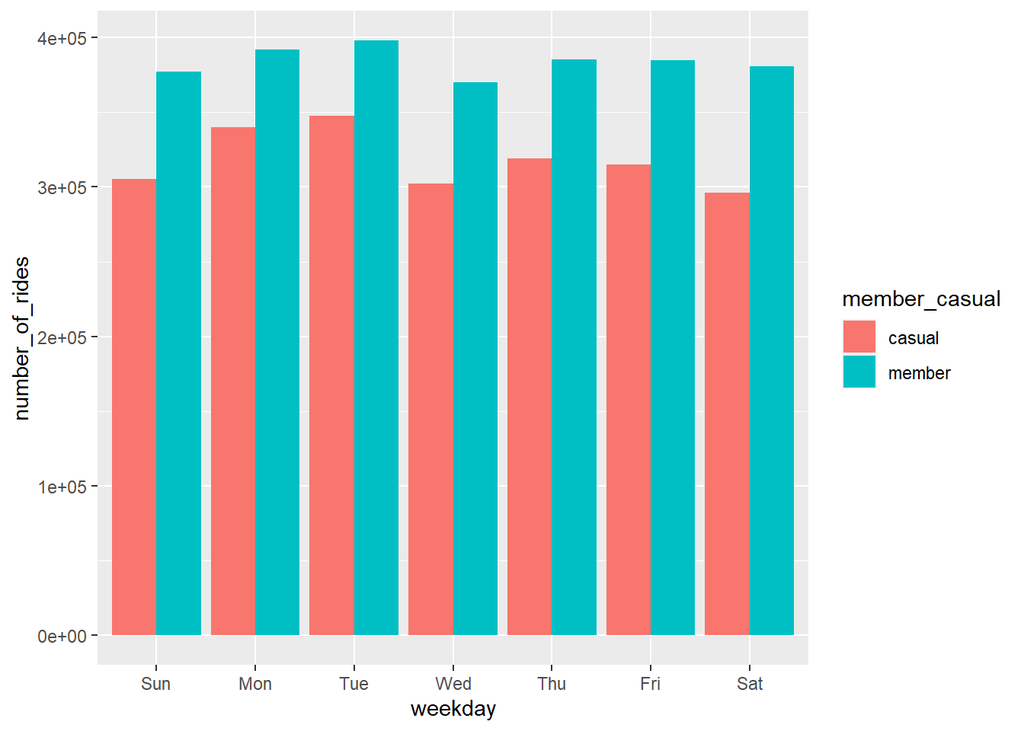

```r
all_trips_v2 %>%
  mutate(weekday = wday(started_at, label = TRUE)) %>%
  group_by(member_casual, weekday) %>%
  summarise(number_of_rides = n()
            ,average_duration = mean(as.numeric(ride_length))) %>%
  arrange(member_casual, weekday)  %>%
  ggplot(aes(x = weekday, y = number_of_rides, fill = member_casual)) +
  geom_col(position = "dodge")
```

Creating bar charts using ggplot() to visualise the average duration by rider type for the days of the week.

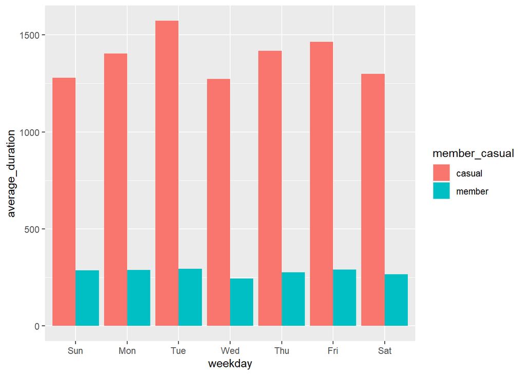

```r
all_trips_v2 %>%
  mutate(weekday = wday(started_at, label = TRUE)) %>%
  group_by(member_casual, weekday) %>%
  summarise(number_of_rides = n()
            ,average_duration = mean(ride_length)) %>%
  arrange(member_casual, weekday)  %>%
  ggplot(aes(x = weekday, y = average_duration, fill = member_casual)) +
  geom_col(position = "dodge")
```